# 16 Continuous data

Author

Vladimir Buskin

## 16.1 Suggested reading

> Heumann et al. (2022: Chapter 3)

## 16.2 Preparation

We will use the dataset from the previous unit:

```r
# Libraries
library("readxl")
library("tidyverse")

# Load data from working directory
cl.order <- read_xlsx("Paquot_Larsson_2020_data.xlsx")
```

## 16.3 Measures of central tendency

### 16.3.1 The mean

A useful summary statistic is the arithmetic mean $\bar{x}$. Consider a continuous variable $X$ with observations $\{x_1, x_2, ..., x_n\}$ from a sample of size $n$. The sample mean $\bar{x}$ then corresponds to

$$\bar{x} = \frac{x_1 + x_2 + ... + x_n}{n} \\ = \frac{1}{n}\sum_{i=1}^n{x_i}.
\tag{16.1}$$

**Hold on, what does this large Σ symbol mean?**

The summation symbol $\sum$ (Greek ‘upper-case sigma’) is a concise way to express the sum of a sequence of numbers.

It works like this:

- The expression below the $\sum$ (e.g., $i = 1$) indicates the starting value of the index $i$.
- The number above the $\sum$ (e.g., $n$) is the ending value of the index $i$.
- The expression to the right of the $\sum$ (e.g., $x_i$) is the term to be summed.

For instance, the more general expression $\sum_{i=1}^n{x_i}$ means “sum the values of $x_i$ starting from $i = 1$ up to $i = n$.” In other words, it adds up the values $x_1 + x_2 + \dots + x_n$.

In R, we can obtain the average value of a numeric vector with the `mean()` function. Let’s do that for the length of main clauses found in the `cl.order` data:

```r
mean(cl.order$LEN_MC)
```

```
[1] 9.265509
```

The output returned by this function provides a one-value summary of all observations contained in `LEN_MC`. Because the the mean $\bar{x}$ takes into account all data points, it is prone to the influence of **outliers**, i.e., extreme values.

The distribution of continuous variables is best visualised in terms of histograms or density plots, which are illustrated for `LEN_MC`. The blue line indicates the sample mean.

**Histogram (ggplot2)**

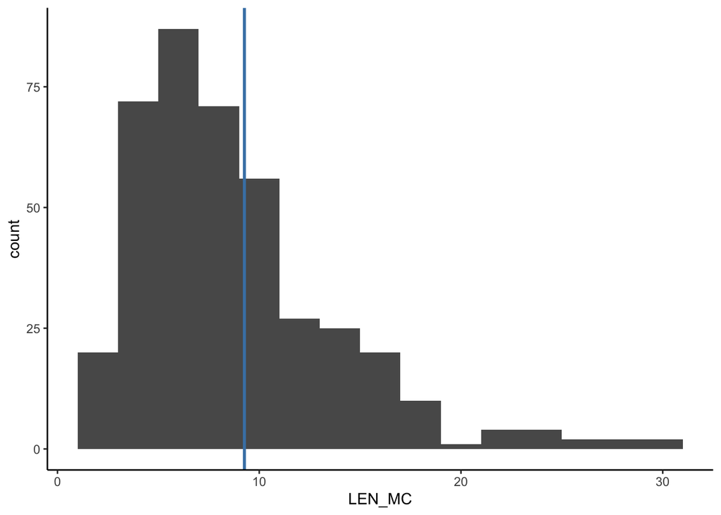

```r
# Plot distribution of LEN_MC
cl.length.hist <- ggplot(cl.order, aes(x = LEN_MC)) +
                  geom_histogram(binwidth = 2)

cl.length.hist +
  # Add mean
  geom_vline(aes(xintercept = mean(LEN_MC)),
             color = "steelblue",
             linewidth = 1) +
  theme_classic()
```

**Density plot (ggplot2)**

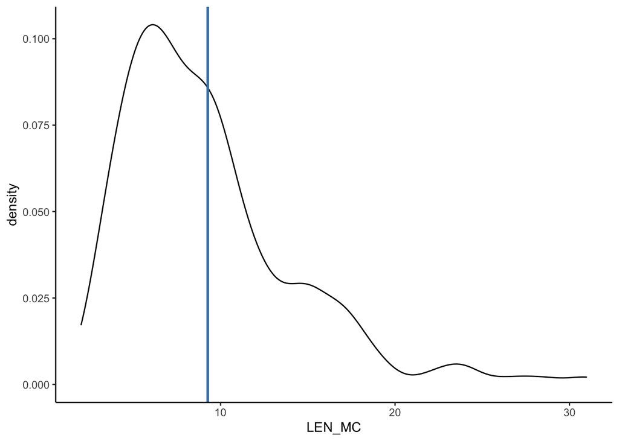

```r
# Plot distribution of LEN_MC
cl.length.dens <- ggplot(cl.order, aes(x = LEN_MC)) +
                  geom_density()

cl.length.dens +
  # Add mean
  geom_vline(aes(xintercept = mean(LEN_MC)),
             color = "steelblue",
             linewidth = 1) +
  theme_classic()
```

**Histogram (Base R)**

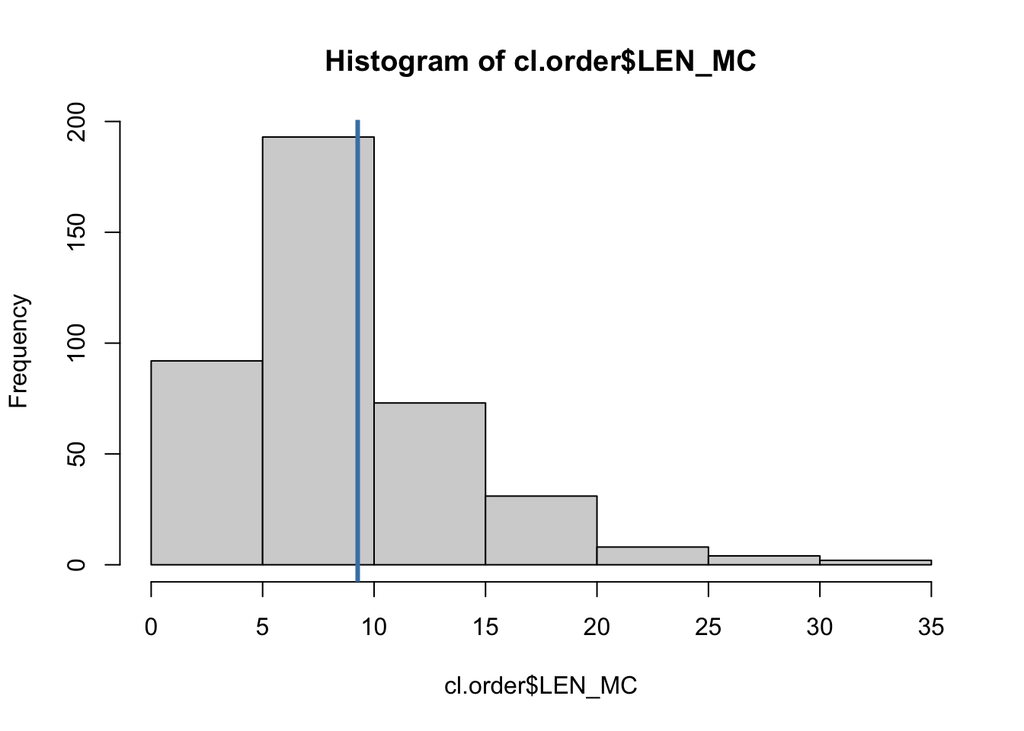

```r
hist(cl.order$LEN_MC)
  abline(v=mean(cl.order$LEN_MC),lwd=3, col = "steelblue")
```

**Density plot (Base R)**

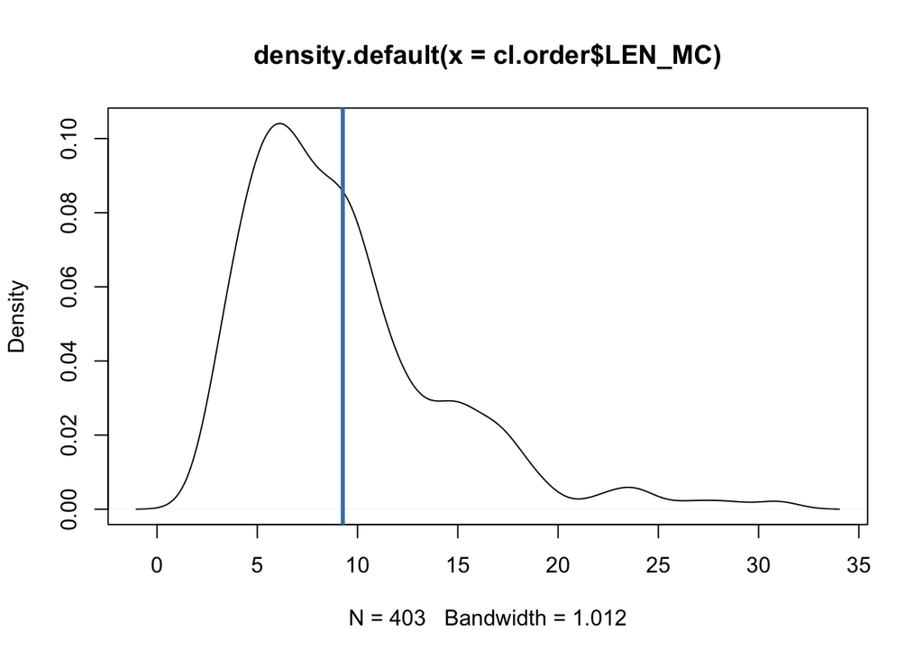

```r
plot(density(cl.order$LEN_MC))
  abline(v=mean(cl.order$LEN_MC),lwd=3, col = "steelblue")
```

### 16.3.2 The median

The `median()` function computes the “the halfway point of the data (50% of the data are above the median; 50% of the data are below” (Winter 2020: 58). As such, it is the measure of choice for data with many outliers as well as for ordinal data (e.g. Likert-scale ratings).

$$\tilde{x}_{0.5} =
\begin{cases}
x_{((n+1)/2)} & \text{if } n \text{ is odd.} \\
\frac{1}{2}(x_{n/2}+x_{(n/2+1)}) & \text{if } n \text{ is even.}
\end{cases}
\tag{16.2}$$

```r
median(cl.order$LEN_MC)
```

```
[1] 8
```

**Histogram (ggplot2)**

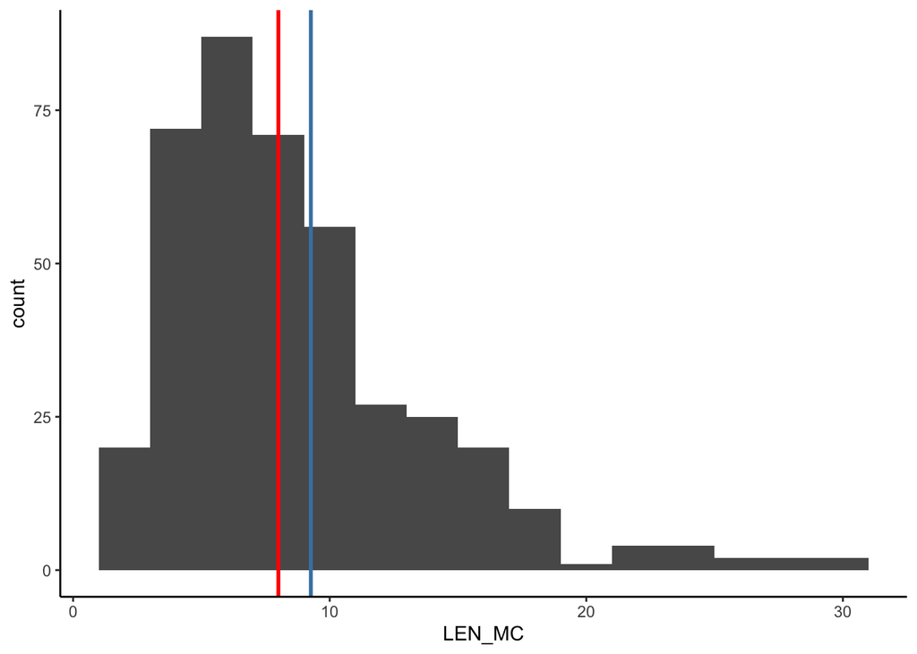

```r
cl.length.hist +
  # Add mean
  geom_vline(aes(xintercept = mean(LEN_MC)), color = "steelblue", linewidth = 1) +
  # Add median
  geom_vline(aes(xintercept = median(LEN_MC)), color = "red", linewidth = 1) +
  theme_classic()
```

**Density plot (ggplot2)**

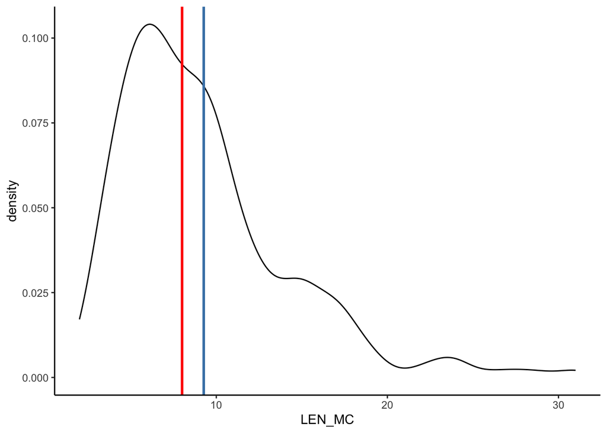

```r
cl.length.dens +
  # Add mean
  geom_vline(aes(xintercept = mean(LEN_MC)), color = "steelblue", linewidth = 1) +
  # Add median
  geom_vline(aes(xintercept = median(LEN_MC)), color = "red", linewidth = 1) +
  theme_classic()
```

**Histogram (Base R)**

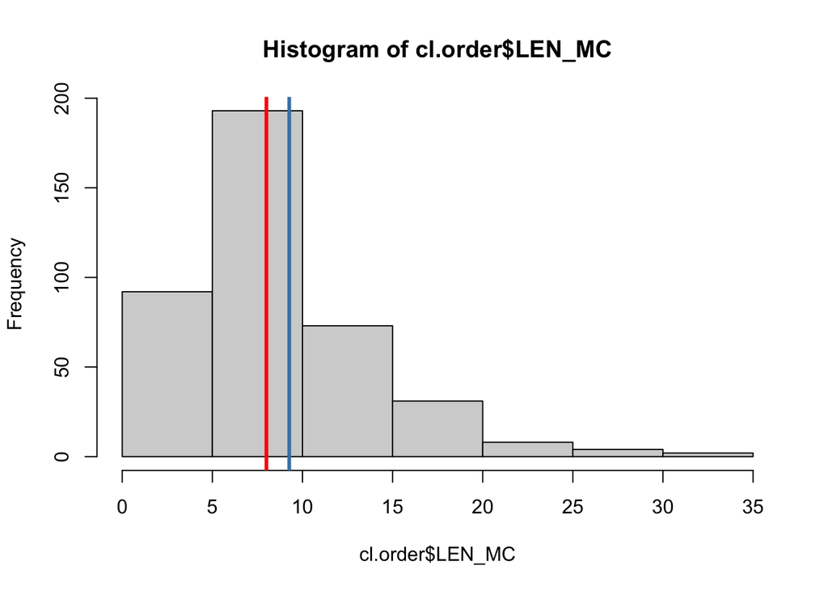

```r
hist(cl.order$LEN_MC)
  abline(v=mean(cl.order$LEN_MC),lwd=3, col = "steelblue")
  abline(v=median(cl.order$LEN_MC),lwd=3, col = "red")
```

**Density plot (Base R)**

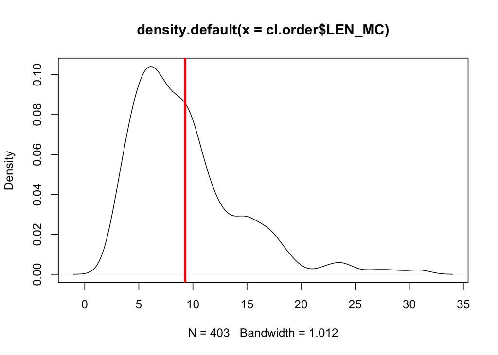

```r
plot(density(cl.order$LEN_MC))
  abline(v=mean(cl.order$LEN_MC),lwd=3, col = "steelblue")
  abline(v=mean(cl.order$LEN_MC),lwd=3, col = "red")
```

### 16.3.3 Sample variance and standard deviation

In order to assess how well the mean represents the data, it is instructive to compute the **variance** `var()` and the **standard deviation** `sd()` for a sample. The component $\sum_{i=1}^n (x_i - \bar{x})^2$ is also known as the **squared error**.

The sample variance $s^2$ is defined as

$$s^2 = \frac{1}{n}\sum_{i=1}^n{(x_i - \bar{x})^2}.
\tag{16.3}$$

In other words, it stands for the average squared deviation of all observations from the sample mean.

```r
var(cl.order$LEN_MC)
```

```
[1] 25.12585
```

Correspondingly, the standard deviation of the mean is the square root of the variance:

$$s = \sqrt{\frac{1}{n}\sum_{i=1}^n{(x_i - \bar{x})^2}}
\tag{16.4}$$

```r
sd(cl.order$LEN_MC)
```

```
[1] 5.012569
```

**Visualisation**:

**Example 1**

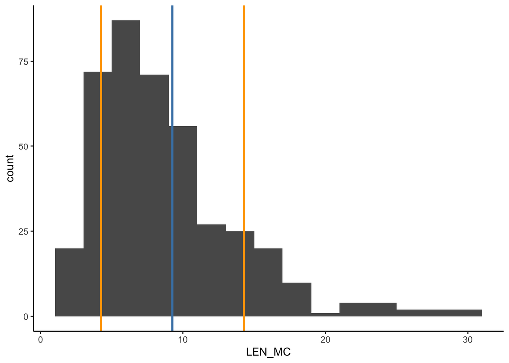

```r
cl.length.hist +
  # Add verticle line for the mean
  geom_vline(aes(xintercept = mean(LEN_MC)), color = "steelblue", linewidth = 1) +
  # Add -1sd
  geom_vline(aes(xintercept = mean(LEN_MC) - sd(LEN_MC)), color = "orange", linewidth = 1) +
  # Add +1sd
  geom_vline(aes(xintercept = mean(LEN_MC) + sd(LEN_MC)), color = "orange", linewidth = 1) +
  theme_classic()
```

**Example 2**

```r
# Create data frame with mean and sd for each clause ORDER

cl.order %>%
  # Select variables of interest
  select(ORDER, LEN_MC) %>%
  # Group results of following operations by ORDER
  group_by(ORDER) %>%
    # Create grouped summary of mean and sd for each ORDER
    summarise(mean = mean(LEN_MC),
                sd = sd(LEN_MC)) -> cl_mean_sd; cl_mean_sd
```

```
# A tibble: 2 × 3
  ORDER  mean    sd
  <chr> <dbl> <dbl>
1 mc-sc  9.04  4.91
2 sc-mc  9.75  5.22
```

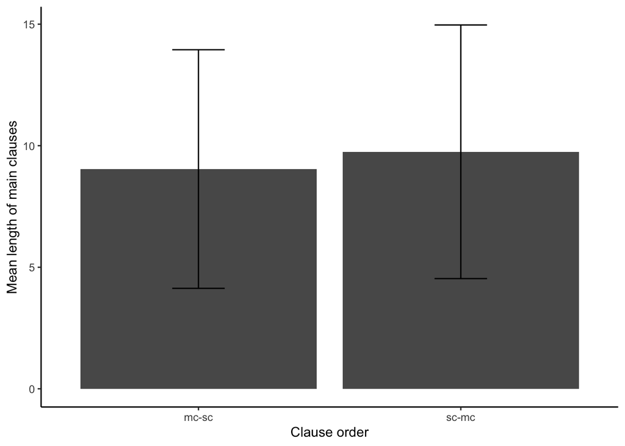

```r
# Plot results

ggplot(cl_mean_sd, aes(x = ORDER, y = mean)) +
  # Barplot with a specific variable mapped onto y-axis
  geom_col() +
  # Add mean and standard deviation to the plot
  geom_errorbar(aes(x = ORDER,
                    ymin = mean-sd,
                    ymax = mean+sd), width = .2) +
  theme_classic() +
  labs(y = "Mean length of main clauses", x = "Clause order")
```

### 16.3.4 Quantiles

While `median()` divides the data into two equal sets (i.e., two 50% quantiles), the `quantile()` function makes it possible to partition the data further.

```r
quantile(cl.order$LEN_MC)
```

```
  0%  25%  50%  75% 100%
   2    6    8   11   31
```

`quantile(x, 0)` and `quantile(x, 1)` thus show the minimum and maximum values, respectively.

```r
quantile(cl.order$LEN_MC, 0)
```

```
0%
 2
```

```r
quantile(cl.order$LEN_MC, 1)
```

```
100%
  31
```

### 16.3.5 Quartiles and boxplots

Consider the distribution of clause length by clause order:

**Boxplot (Base R)**

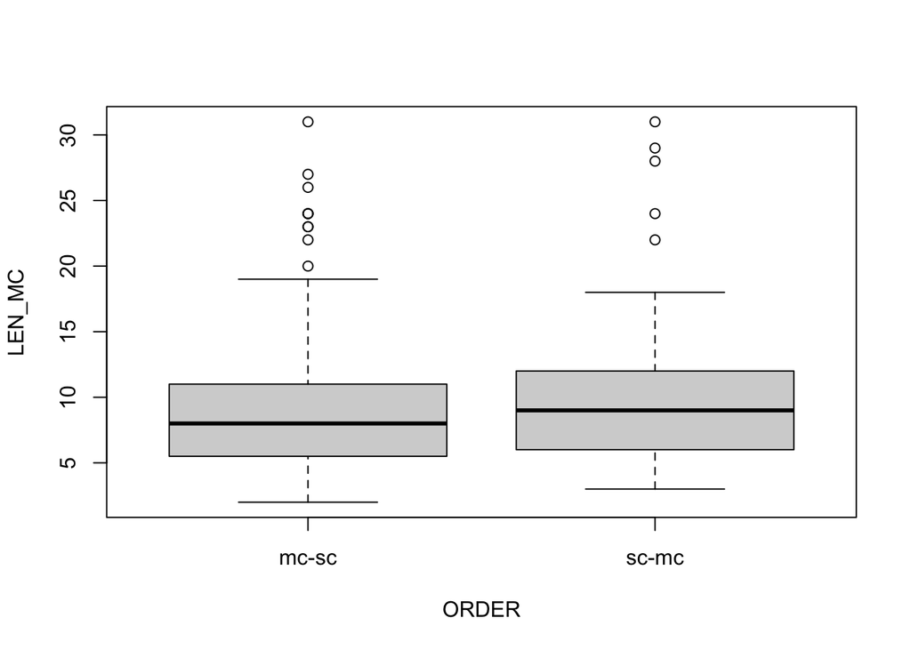

```r
boxplot(LEN_MC ~ ORDER, cl.order)
```

**Boxplot (ggplot2)**

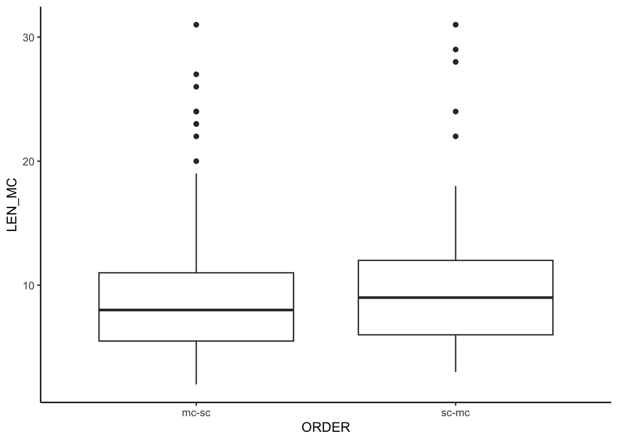

```r
ggplot(cl.order, aes(x = ORDER, y = LEN_MC)) +
  geom_boxplot() +
  theme_classic()
```

Compare it to the corresponding rotated density plot:

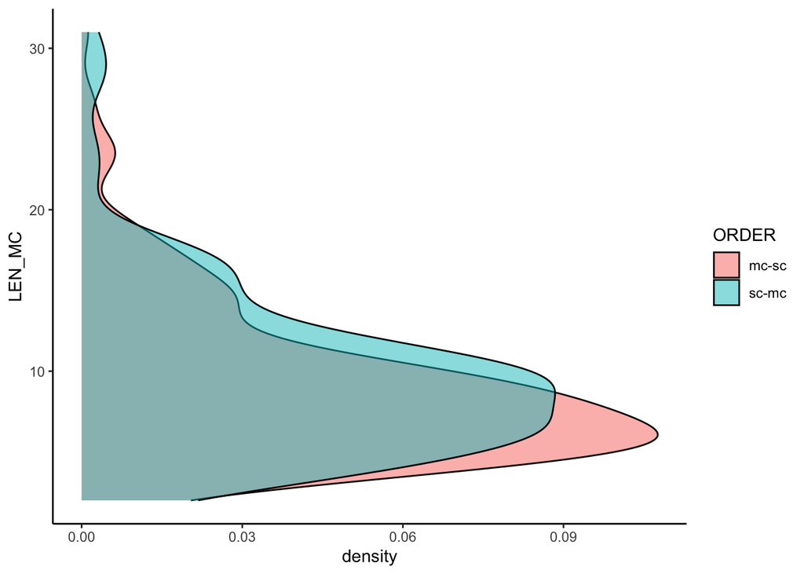

```r
ggplot(cl.order, aes(x = LEN_MC, fill = ORDER)) +
  geom_density(alpha = 0.5) +
  coord_flip() +
  theme_classic()
```

## 16.4 Visualising mixed data

### 16.4.1 A numerical and categorical variable

- Boxplot with `geom_boxplot()`

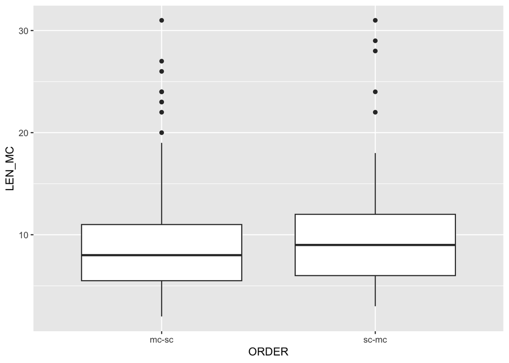

```r
ggplot(cl.order, aes(x = ORDER, y = LEN_MC)) +
  geom_boxplot()
```

- Densitiy plot using the optional arguments `color` and/or `fill`

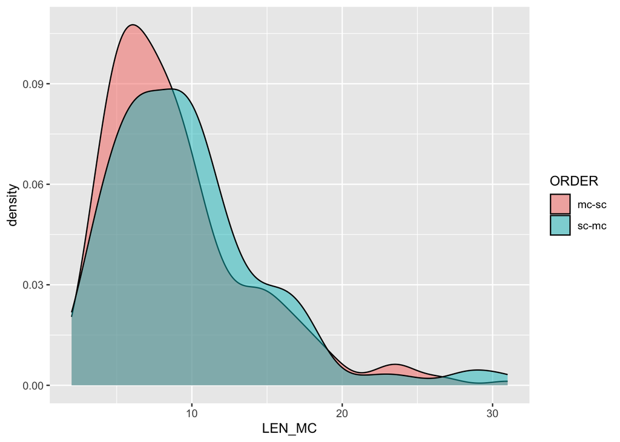

```r
ggplot(cl.order, aes(x = LEN_MC, fill = ORDER)) +
  geom_density(alpha = 0.5)
```

- A barplot with `geom_col()`

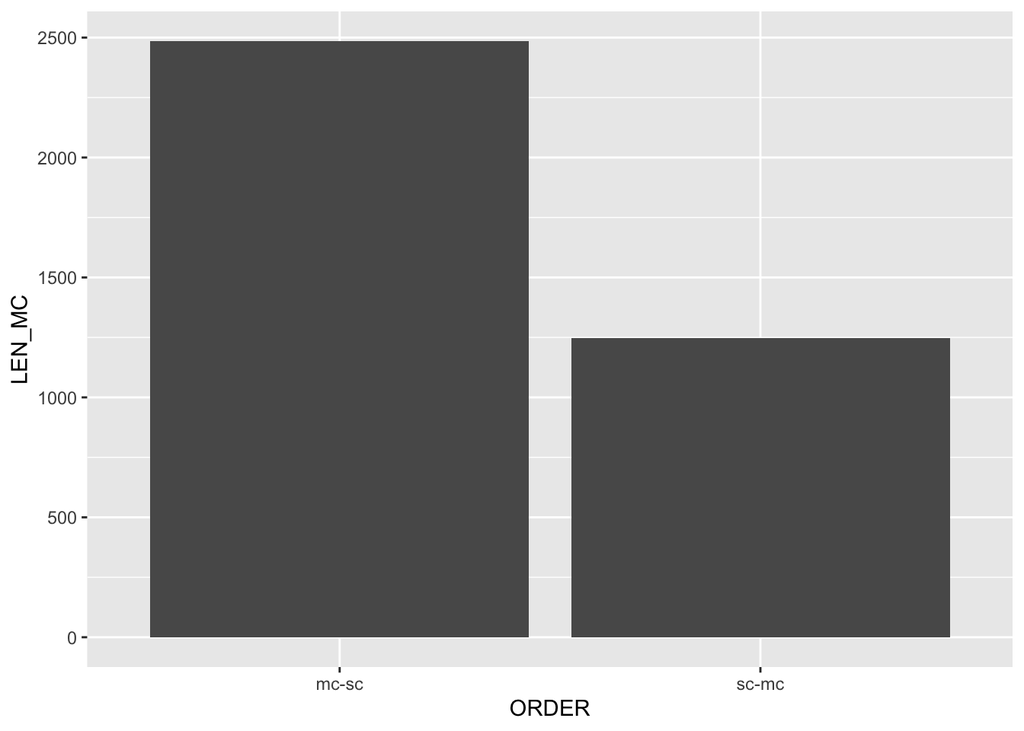

```r
ggplot(cl.order, aes(x = ORDER, y = LEN_MC)) +
  geom_col(aes(x = ORDER, y = LEN_MC))
```

### 16.4.2 Multivariate plots

- Advanced scatterplot with four variables: `LEN_MC` (x), `LEN_SC` (y), `ORDER` (colour) and `SUBORDTYPE` (shape)

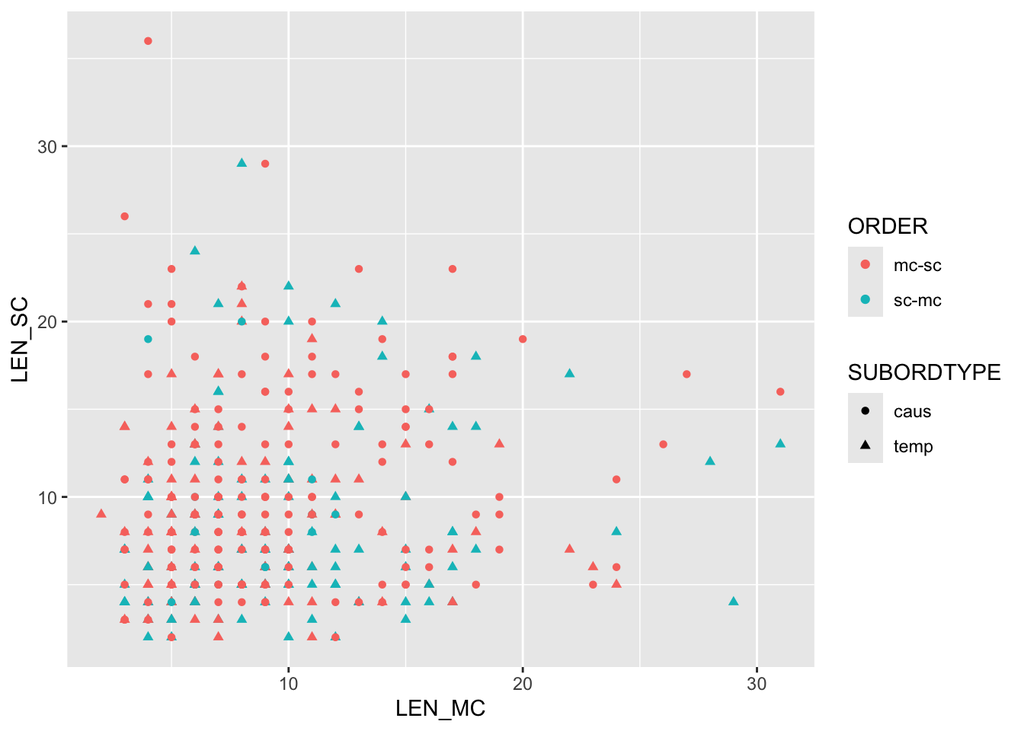

```r
# 4 variables
ggplot(cl.order, aes(x = LEN_MC, y = LEN_SC)) +
  geom_point(aes(color = ORDER, shape = SUBORDTYPE))
```

- Facets

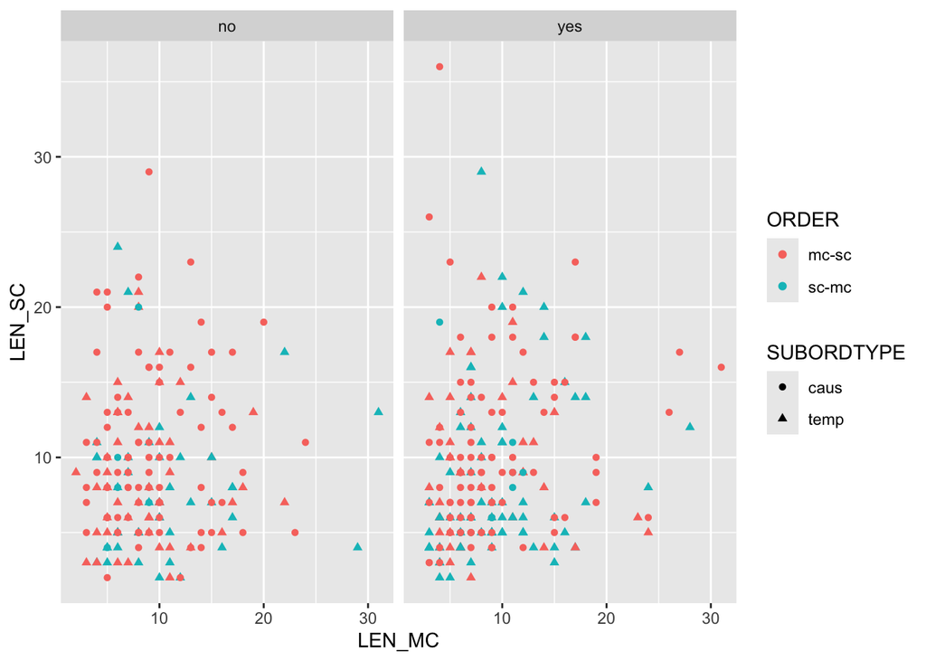

```r
# 5 variables
ggplot(cl.order, aes(x = LEN_MC, y = LEN_SC)) +
  geom_point(aes(color = ORDER, shape = SUBORDTYPE)) +
  facet_wrap(~MORETHAN2CL)
```

Heumann, Christian, Michael Schomaker, and Shalabh. 2022. *Introduction to Statistics and Data Analysis: With Exercises, Solutions and Applications in r*. 2nd ed. Cham: Springer. https://doi.org/10.1007/978-3-031-11833-3.

Winter, Bodo. 2020. *Statistics for Linguists: An Introduction Using r*. New York; London: Routledge.